# MA0501 – Tarea 4

# Ejercicio 8

**Instrucción del ejercicio 8**

Use el algoritmo de Hermite para construir el polinomio interpolante de Hermite dada la siguiente tabla:

| $x$ | $f(x)$ | $f'(x)$ |
| --- | --- | --- |
| 0.2 | 0.9798652 | 0.20271 |
| 0.4 | 0.9177710 | 0.42279 |
| 0.6 | 0.8080348 | 0.68414 |
| 0.8 | 0.6386093 | 1.02964 |
| 1.0 | 0.3843735 | 1.55741 |

Grafique este polinomio.

**Solución**

```r
nodos     <- c(0.2, 0.4, 0.6, 0.8, 1.0)
valores   <- c(0.9798652, 0.9177710, 0.8080348, 0.6386093, 0.3843735)
derivadas <- c(0.20271,   0.42279,   0.68414,   1.02964,   1.55741)

hermite.newton(nodos, valores, derivadas, 0.2)
```

```
$valor
[1] 0.9798652

$tabla
           [,1]       [,2]       [,3]      [,4]      [,5]       [,6]      [,7]
 [1,] 0.9798652  0.0000000   0.000000   0.00000    0.0000     0.0000     0.000
 [2,] 0.9798652  0.2027100   0.000000   0.00000    0.0000     0.0000     0.000
 [3,] 0.9177710 -0.3104710  -2.565905   0.00000    0.0000     0.0000     0.000
 [4,] 0.9177710  0.4227900   3.666305  31.16105    0.0000     0.0000     0.000
 [5,] 0.8080348 -0.5486810  -4.857355 -21.30915 -131.1755     0.0000     0.000
 [6,] 0.8080348  0.6841400   6.164105  55.10730  191.0411   805.5416     0.000
 [7,] 0.6386093 -0.8471275  -7.656337 -34.55111 -224.1460  -691.9786 -2495.867
 [8,] 0.6386093  1.0296400   9.383837  85.20087  299.3800  1308.8149  3334.656
 [9,] 0.3843735 -1.2711790 -11.504095 -52.21983 -343.5518 -1071.5529 -3967.280
[10,] 0.3843735  1.5574100  14.142945 128.23520  451.1376  1986.7234  5097.127
           [,8]      [,9]    [,10]
 [1,]     0.000      0.00     0.00
 [2,]     0.000      0.00     0.00
 [3,]     0.000      0.00     0.00
 [4,]     0.000      0.00     0.00
 [5,]     0.000      0.00     0.00
 [6,]     0.000      0.00     0.00
 [7,]     0.000      0.00     0.00
 [8,]  9717.538      0.00     0.00
 [9,] -9127.419 -23556.20     0.00
[10,] 15107.344  30293.45 67312.06

$coeficientes
 [1]  9.798652e-01  2.027100e-01 -2.565905e+00  3.116105e+01 -1.311755e+02
 [6]  8.055416e+02 -2.495867e+03  9.717538e+03 -2.355620e+04  6.731206e+04
```

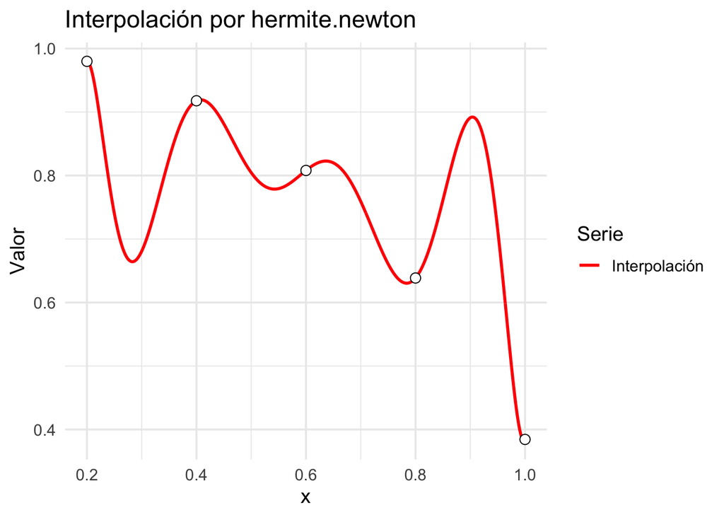

```r
graficar.polinomio(nodos, 0.2, 1, hermite.newton, valores = valores, derivadas = derivadas)
```

# Ejercicio 9

**Instrucción del ejercicio 9**

Use el algoritmo de Diferencias Divididas para calcular el polinomio de interpolación de Lagrange $p(x)$ de cuarto grado para:

$$f(x) = x^3 \sin(x)$$

con nodos $x_0 = 1$, $x_1 = 2$, $x_2 = 3$, $x_3 = 4$ y $x_4 = 5$.

Grafique en un mismo plano $f(x)$ y $p(x)$ y luego imprima.

# Ejercicio 10

**Instrucción del ejercicio 10**

Probar que los polinomios $L_k(x)$ vistos en clase se pueden expresar de la forma:

$$L_k(x) = \frac{\psi(x)}{(x - x_k)\psi'(x_k)}$$

donde:

$$\psi(x) = \prod_{j=0}^n (x - x_j)$$

y que por lo tanto el polinomio interpolante de Lagrange se puede expresar como:

$$p(x) = \psi(x) \sum_{k=0}^n \frac{f(x_k)}{(x - x_k)\psi'(x_k)}.$$

**Solución**

Partimos de la definición vista en clase del polinomio de Lagrange:

$$L_k(x) = \prod_{\substack{j = 0 \\ j \ne k}}^n \frac{x - x_j}{x_k - x_j}$$

Ahora definimos el polinomio:

$$\psi(x) = \prod_{j=0}^n (x - x_j)$$

Este se puede factorizar como:

$$\psi(x) = (x - x_k) \prod_{\substack{j=0 \\ j \ne k}}^n (x - x_j)
\quad \Rightarrow \quad
\prod_{\substack{j=0 \\ j \ne k}}^n (x - x_j) = \frac{\psi(x)}{x - x_k}$$

También observamos que la derivada de $\psi(x)$ evaluada en $x_k$ es:

$$\psi'(x_k) = \prod_{\substack{j = 0 \\ j \ne k}}^n (x_k - x_j)$$

**Demostración de $\psi'(x)$ por inducción**

Queremos probar que si definimos el polinomio:

$$\psi(x) = \prod_{j=0}^n (x - x_j)$$

entonces, para cualquier $k \in \{0, 1, \dots, n\}$, se cumple:

$$\psi'(x_k) = \prod_{\substack{j=0 \\ j \ne k}}^n (x_k - x_j)$$

Esta es la derivada del producto evaluada en uno de los nodos $x_k$. Usaremos **inducción matemática sobre $n$**.

**Paso base: $n = 1$**

$$\psi(x) = (x - x_0)(x - x_1)$$

Entonces su derivada es:

$$\psi'(x) = (x - x_0)'(x - x_1) + (x - x_0)(x - x_1)' = (x - x_1) + (x - x_0)$$

Evaluamos en $x = x_0$:

$$\psi'(x_0) = (x_0 - x_1) + 0 = x_0 - x_1 = \prod_{\substack{j=0 \\ j \ne 0}}^1 (x_0 - x_j)$$

Y en $x = x_1$:

$$\psi'(x_1) = 0 + (x_1 - x_0) = x_1 - x_0 = \prod_{\substack{j=0 \\ j \ne 1}}^1 (x_1 - x_j)$$

Por tanto, el paso base se cumple.

**Paso inductivo: suponer cierto para $n$, probar para $n+1$**

Supongamos que para:

$$\psi_n(x) = \prod_{j=0}^n (x - x_j)$$

se cumple:

$$\psi_n'(x_k) = \prod_{\substack{j=0 \\ j \ne k}}^n (x_k - x_j)$$

Queremos probar que para:

$$\psi_{n+1}(x) = \psi_n(x)(x - x_{n+1})$$

se cumple:

$$\psi_{n+1}'(x_k) = \prod_{\substack{j=0 \\ j \ne k}}^{n+1} (x_k - x_j)$$

Aplicamos la derivada del producto:

$$\psi_{n+1}'(x) = \psi_n'(x)(x - x_{n+1}) + \psi_n(x)$$

Evaluamos en $x = x_k$ con $k \le n$. Como $\psi_n(x_k) = 0$ (por definición de raíz), el segundo término desaparece:

$$\psi_{n+1}'(x_k) = \psi_n'(x_k)(x_k - x_{n+1})$$

Por hipótesis inductiva:

$$\psi_n'(x_k) = \prod_{\substack{j=0 \\ j \ne k}}^n (x_k - x_j)$$

Entonces:

$$\psi_{n+1}'(x_k) = \left( \prod_{\substack{j=0 \\ j \ne k}}^n (x_k - x_j) \right)(x_k - x_{n+1})
= \prod_{\substack{j=0 \\ j \ne k}}^{n+1} (x_k - x_j)$$

Lo cual demuestra que la fórmula también es válida para $n+1$.

**Conclusión:**

Por el principio de inducción matemática, se cumple que:

$$\boxed{
\psi'(x_k) = \prod_{\substack{j=0 \\ j \ne k}}^n (x_k - x_j)
}$$

para todo $k \in \{0, 1, \dots, n\}$.

ya que al derivar el producto total y evaluar en $x_k$, solo sobrevive el término en el que se deriva $(x - x_k)$.

Sustituyendo todo en la fórmula original de $L_k(x)$:

$$L_k(x) = \frac{\prod_{\substack{j = 0 \\ j \ne k}}^n (x - x_j)}{\prod_{\substack{j = 0 \\ j \ne k}}^n (x_k - x_j)}
= \frac{\psi(x)}{(x - x_k)\psi'(x_k)}$$

Esto completa la prueba de la fórmula para $L_k(x)$.

Finalmente, como el polinomio interpolante de Lagrange se define como:

$$p(x) = \sum_{k=0}^n f(x_k) L_k(x)$$

entonces sustituyendo la expresión obtenida para $L_k(x)$:

$$p(x) = \sum_{k=0}^n f(x_k) \frac{\psi(x)}{(x - x_k)\psi'(x_k)}
= \psi(x) \sum_{k=0}^n \frac{f(x_k)}{(x - x_k)\psi'(x_k)}$$

# Ejercicio 11

**Instrucción del ejercicio 11**

Demostrar que si $f(x)$ es un polinomio de grado menor o igual a $n$, entonces el polinomio de grado menor o igual a $n$ que interpola $f(x)$ en $x_0, x_1, \ldots, x_n$ es el mismo $f(x)$.

**Solución**

Sea $f(x)$ un polinomio de grado menor o igual a $n$ y $P_n(x)$ el polinomio que lo interpola en $x_0, x_1,..., x_n$.

Note que $f^{(n+1)}(x) = 0$, pues es un polinomio de grado menor o igual a n.

Además, se sabe que el error absoluto entre $f(x)$ y su interpolacion viene dado por:

$|f(x) - P_n(x)| = |\dfrac{f^{(n+1)}(\psi_x)}{(n+1)!}(x - x_0)(x - x_1)\cdot\cdot\cdot(x-x_n)|$, con $\psi_x \in [a,b]$, donde $[a,b]$ es el intervalo donde estamos interpolando.

Juntando estas dos cosas, se concluye que $|f(x) - P_n(x)| = 0 \Rightarrow f(x) = P_n(x)$

# Ejercicio 12

**Instrucción del ejercicio 12**

Usar el ejercicio anterior para probar que:

$$\sum_{i=0}^n L_i(x) = 1$$

# Ejercicio 13

**Instrucción del ejercicio 13**

Para las siguientes funciones:

- $f(x)=3x^{2}\ln(x)+2x$ con nodos $x_{0}=1$, $x_{1}=1.5$, $x_{2}=2$, $x_{3}=2.5$ y $x_{4}=3$.
- $f(x)=x^{2}\sin(x)-3\cos(x)$ con nodos $x_{0}=1$, $x_{1}=2$, $x_{2}=3$, $x_{3}=4$ y $x_{4}=5$.
- $f(x)=x\cos(x)-2x^{2}+3x-1$ con nodos $x_{0}=1$, $x_{1}=2$, $x_{2}=3$, $x_{3}=4$ y $x_{4}=5$.
1. Encuentre el polinomio de interpolación de Lagrange $P^\star(x)$ en los nodos indicados, grafique $f(x)$ y $P^\star(x)$ en el mismo plano.
2. Encuentre el polinomio de interpolación usando Splines cúbicos $P^{\star\star}(x)$ en los nodos indicados, grafique $f(x)$ y $P^{\star\star}(x)$ en el mismo plano; luego imprima.
3. Encuentre el polinomio de interpolación de Hermite $P^{\star\star\star}(x)$ en los nodos indicados, grafique $f(x)$ y $P^{\star\star\star}(x)$ en el mismo plano.
4. Grafique $f(x)$, $P^\star(x)$, $P^{\star\star}(x)$ y $P^{\star\star\star}(x)$ en el mismo plano. ¿Qué se puede concluir?

# Ejercicio 14

**Instrucción del ejercicio 14**

¿Existen $a,b,c,d$ tal que la función:

$$S(x)=
\begin{cases}
ax^3+x^2+cx, & -1\le x\le 0,\\[4pt]
bx^3+x^2+dx, & \ \ 0\le x\le 1
\end{cases}$$

sea el spline cúbico natural que coincide con la función $f(x)=|x|$ en los nodos $-1,0,1$?

**Solución**

Una de las primeras condiciones que deben ocurrir es que $S_{-1}(-1) = 1$ y $S_0(1) = 1$

$$\begin{equation*}
\begin{cases}
S_{-1}(-1) =-a + 1 - c = 1\\
S_0(1) = b + 1 + d = 1
\end{cases}
\Longrightarrow
\begin{cases}
a = -c \\
b = -d
\end{cases}
\end{equation*}$$

Por otra parte, debe suceder que $S'_{-1}(0) = S'_0(0)$

$$3ax^2 +2x +c = 3bx^2 +2x +d \text{ en $x = 0$}\Rightarrow c = d \Rightarrow a = -c = -d = b \Rightarrow a = b$$

Finalmente, se debe cumplir la condicion natural: $S''_{-1}(-1) = 0$ y $S''_0(1) = 0$

$$\begin{equation*}\begin{cases}
6a(-1) + 2 = 0\\
6b(1) + 2 = 0
\end{cases}
\Longrightarrow
\begin{cases}
a = 1/3\\
b = -1/3
\end{cases}
\Longrightarrow a = -b \Rightarrow \Leftarrow\end{equation*}$$

Por lo tanto, no existen $a,b,c,d$ tal que $S(x)$ sea el spline cubico natural de $|x|$ en los nodos $-1, 0, 1$

# Ejercicio 15

**Instrucción del ejercicio 15**

Encuentre los valores de $a,b,c,d$ y $e$ tal que la función $S(x)$ es un spline cúbico natural:

$$S(x)=
\begin{cases}
a+b(x-1)+c(x-1)^2+d(x-1)^3, & 0\le x\le 1,\\[4pt]
(x-1)^3+ex^2-1, & 1\le x\le 2.
\end{cases}$$

# Ejercicio 16

**Instrucción del ejercicio 16**

Encuentre los valores de $a,b,c$ y $d$ tal que la función $S(x)$ es un spline cúbico y cumple que $\displaystyle \int_{0}^{2}\!\big[S''(x)\big]^2\,dx$ es mínimo (esta condición sustituye a la condición para ser spline natural o sujeto):

$$S(x)=
\begin{cases}
3+x-9x^3, & 0\le x\le 1,\\[4pt]
a+b(x-1)+c(x-1)^2+d(x-1)^3, & 1\le x\le 2.
\end{cases}$$

**Solución**

1. Condiciones de continuidad en $x=1$ (de $S$ y $S'$) y de empalme de $S''$:
- Para $x\le 1$:  
  $S_0(x)=3+x-9x^3,\;\; S_0'(x)=1-27x^2,\;\; S_0''(x)=-54x.$
- Para $x\ge 1$:  
  $S_1(x)=a+b(x-1)+c(x-1)^2+d(x-1)^3,$  
  $S_1'(x)=b+2c(x-1)+3d(x-1)^2,$  
  $S_1''(x)=2c+6d(x-1).$

En $x=1$:
$$\begin{align*}
S_0(1)=3+1-9=-5 &\Rightarrow a=-5,\\
S_0'(1)=1-27=-26 &\Rightarrow b=-26,\\
S_0''(1)=-54 = 2c &\Rightarrow c=-27.
\end{align*}$$

2. Minimización de la energía de curvatura:
   $$J(d)=\int_{0}^{1}\!\big[S_0''(x)\big]^2 dx+\int_{1}^{2}\!\big[S_1''(x)\big]^2 dx.$$

El primer término no depende de $d$:
$$\int_{0}^{1}\!\big(-54x\big)^2 dx=\frac{54^2}{3}.$$

Para el segundo, ponga $y=x-1\in[0,1]$, con $A=-54$ y $B=6d$:
$$\begin{align*}
\int_{1}^{2}\!\big(-54+6d(x-1)\big)^2 dx
&=\int_{0}^{1} (A+By)^2 dy \\
&= A^2 + AB + \frac{B^2}{3}
= 2916 - 324d + 12d^2.
\end{align*}$$

Luego
$$J(d)=\text{cte} + 12d^2 - 324d,
\qquad
J'(d)=24d-324=0 \Rightarrow d=\frac{324}{24}=13.5.$$

**Resultado final:**
$$\boxed{\,a=-5,\quad b=-26,\quad c=-27,\quad d=13.5\,}$$
$\blacksquare$

# Ejercicio 17

**Instrucción del ejercicio 17**

El objetivo de este ejercicio es estudiar e implementar un algoritmo para **Aproximación discreta por mínimos cuadrados**. Para esto:

1. El problema en general es aproximar una tabla de datos $\{(x_i,y_i)\mid i=1,2,\ldots,m\}$ por un polinomio de grado $n<m-1$ denotado por
   $$P_n(x)=\sum_{k=0}^{n} a_k x^k.$$
   La idea es encontrar constantes $\{a_k\}_{k=0}^{n}$ tal que se minimice el error:
   $$E=\sum_{i=1}^{m}\big(y_i-P_n(x_i)\big)^2.$$
   Pruebe que este mínimo se alcanza en la solución del sistema de **ecuaciones normales** (n+1)×(n+1) para las incógnitas $\{a_k\}_{k=0}^{n}$ dado por:
   $$\sum_{k=0}^{n} a_k \sum_{i=1}^{m} x_i^{\,j+k}
   \;=\;
   \sum_{i=1}^{m} y_i x_i^{\,j},
   \qquad j=0,1,2,\ldots,n.$$
2. Dada una tabla de datos para $f$, escriba una función en **R** que permita generar el sistema de ecuaciones normales del inciso (a).
3. Luego escriba una función en **R** que encuentre los coeficientes del polinomio de mínimos cuadrados y luego lo grafique.
4. Construir la **aproximación de mínimos cuadrados de grado 3** para la siguiente tabla y **construir el gráfico**.

| $x_i$ | $y_i$ |
| --- | --- |
| 4.0 | 102.56 |
| 4.2 | 113.18 |
| 4.5 | 130.11 |
| 4.7 | 142.05 |
| 5.1 | 167.53 |
| 5.5 | 195.14 |
| 5.9 | 224.87 |
| 6.3 | 256.73 |
| 6.8 | 299.50 |
| 7.1 | 326.72 |

**Solución** a)

Para encontrar el minimo de $E$, hay que derivarlo con respecto a cada uno de los $a_j$, con $j = 0, 1, ..., n$

$$\dfrac{\partial E}{\partial a_j} = 2 \sum_{i = 1}^{m}{(y_i - \sum_{k = 0}^{n}{a_kx_i^k})\cdot \dfrac{-\partial}{\partial a_k}(\sum_{k = 0}^n{a_kx_i^k})}=0$$

Note que $\dfrac{\partial}{\partial a_j}(\sum_{k = 0}^n{a_kx_i^k}) = x_i^j$

$$\Rightarrow \dfrac{\partial E}{\partial a_j} = -2\cdot \sum_{i = 1}^m{(y_i - \sum_{k = 0}^n{a_kx_i^k})\cdot x_i^j} = 0 \\
\Rightarrow -\sum_{i = 1}^m{y_ix_i^j} + \sum_{i = 1}^m \sum_{k = 0}^n {a_kx_i^{k+j}} = 0 \\
\Rightarrow \sum_{k = 0}^n{a_k\sum_{i = 1}^m{x_i^{j+k}}} = \sum_{i = 1}^m{y_ix_i^j}$$

```r
# Funcion para plantear el sistema de ecuaciones asociado al ajuste de minimos cuadrados
# Retorna matriz asociada a los coeficientes (A) y vector de solucion (B)
sistema.minimos <- function(nodos, valores, n){
  stopifnot(is.numeric(nodos), is.numeric(valores),
            length(nodos) == length(valores),
            is.numeric(n), n >= 0, n < length(nodos))
  m <- length(nodos)
  A <- matrix(NA_real_, nrow = n + 1, ncol = n + 1)
  B <- numeric(n + 1)
  for (j in 0:n){
    for (k in 0:n) {
      A[j + 1, k + 1] <- sum(nodos^(j + k))
    }
    B[j + 1] <- sum(nodos^(j) * valores)
  }
  return(list(A = A, B = B))
}
```

```r
# Funcion para encontrar coeficientes del polinomio que surge del ajuste de minimos cuadrados y hacer el grafico del mismo
ajuste.minimos.cuadrados <- function(nodos, valores, n, a, b){
  stopifnot(is.numeric(nodos), is.numeric(valores),
            length(nodos) == length(valores),
            is.numeric(a), is.numeric(b), a < b,
            is.numeric(n), n >= 0)
  sistema <- sistema.minimos(nodos, valores, n)

  coef <- as.numeric(solve(sistema$A, sistema$B))

  # Polinomio ajustado
  f_hat <- function(z) vapply(z, function(zz) sum(coef * zz^(0:n)), numeric(1))

  # Datos para el gráfico
  xi <- seq(a, b, length.out = 400)
  df_plot <- data.frame(x = xi, Hx = f_hat(xi))
  df_pts  <- data.frame(x = nodos, y = valores)

  # Gráfico
  p <- ggplot(df_plot, aes(x = x)) +
    geom_line(aes(y = Hx, color = "Ajuste (MC)"),
              linewidth = 1, linetype = "dashed") +
    scale_color_manual(values = c("Ajuste (MC)" = "red")) +
    geom_point(data = df_pts, aes(x = x, y = y),
               shape = 21, size = 3, fill = "white") +
    labs(title = paste0("Interpolación por ajuste de\nmínimos cuadrados (grado ", n, ")"),
         y = "Valor", color = "Serie") +
    theme_minimal(base_size = 14)

  return(list(coeficientes = coef, f.ajuste = f_hat, grafico = p))
}
```

```
$coeficientes
[1]  3.42909439 -2.37922111  6.84557777 -0.01367456

$f.ajuste
function (z)
vapply(z, function(zz) sum(coef * zz^(0:n)), numeric(1))
<bytecode: 0x134c65ee8>
<environment: 0x132d79138>

$grafico
```

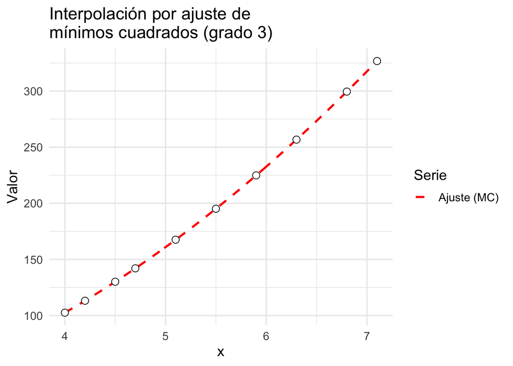

```r
nodos   <- c(4.0, 4.2, 4.5, 4.7, 5.1, 5.5, 5.9, 6.3, 6.8, 7.1)
valores <- c(102.56, 113.18, 130.11, 142.05, 167.53, 195.14, 224.87, 256.73, 299.50, 326.72)
n <- 3
a <- min(nodos)
b <- max(nodos)

x <- ajuste.minimos.cuadrados(nodos, valores, n, a, b)
x
```

# Ejercicio 18

**Instrucción del ejercicio 18**

El objetivo de este ejercicio es **generalizar la aproximación discreta por mínimos cuadrados**.  
Dada una función $f\in C[a,b]$, se requiere un polinomio $\tilde P_n(x)=\sum\limits_{k=0}^{n} a_k x^k$ de manera tal que las constantes $\{a_k\}_{k=0}^{n}$ minimicen el error:

$$E=\int_a^b \big(f(x)-\tilde P_n(x)\big)^2\,dx.$$

Pruebe que este mínimo se alcanza en la solución del sistema de **$(n+1)$ ecuaciones normales** y $(n+1)$ incógnitas $\{a_k\}_{k=0}^{n}$ dado por:

$$\sum_{k=0}^{n} a_k \int_a^b x^{j+k}\,dx \;=\; \int_a^b x^{j} f(x)\,dx,
\qquad j=0,1,2,\ldots,n.
\tag{2}$$

1. Dada una función $f$ escriba una función en **R** que permita **generar el sistema de ecuaciones (2)**.
2. Luego escriba una función en **R** que **encuentre los coeficientes** del polinomio $\tilde P_n(x)$ y luego lo grafique.
3. Encuentre la **aproximación polinómica** $\tilde P_n(x)$ de grado $2$, $4$ y $6$ para $f(x)=\cos(\pi x)$ en el intervalo $[-1,1]$. Además, **construya los gráficos**.

**Solución**

```r
sistema.minimos.integrados <- function(a, b, f, n){
  A <- matrix(NA_real_, nrow = n + 1, ncol = n + 1)
  B <- numeric(n + 1)

  for (j in 0:n) {
    for (k in 0:n) {
      A[j + 1, k + 1] <- integrate(function(x) x^(j + k), a, b)$value
    }
    B[j + 1] <- integrate(function(x) f(x) * x^j, a, b)$value
  }
  return(list(A = A, B = B))
}
```

```r
ajuste.minimos.cuadrados.integrados <- function(a, b, f, n){
  sistema <- sistema.minimos.integrados(a, b, f, n)

  coef <- as.numeric(solve(sistema$A, sistema$B))

  # Polinomio ajustado
  f_hat <- function(z) vapply(z, function(zz) sum(coef * zz^(0:n)), numeric(1))

  # Datos para el gráfico
  xi <- seq(a, b, length.out = 400)
  df_plot <- data.frame(x = xi, Hx = f_hat(xi), fx = f(xi))

  # Gráfico
  p <- ggplot(df_plot, aes(x = x)) +
    geom_line(aes(y = fx, color = "Original"), linewidth = 1) +
    geom_line(aes(y = Hx, color = "Ajuste (MC)"),
              linewidth = 1, linetype = "dashed") +
    scale_color_manual(values = c("Ajuste (MC)" = "red", "Original" = "blue")) +
    labs(title = paste0("Interpolación por ajuste de\nmínimos cuadrados (grado ", n, ")"),
         y = "Valor", color = "Serie") +
    theme_minimal(base_size = 14)

  invisible(list(coeficientes = coef, f_ajuste = f_hat, grafico = p))
}
```

```r
grado.2 <- ajuste.minimos.cuadrados.integrados(-1,1, function(x) cos(pi * x),2)
grado.4 <- ajuste.minimos.cuadrados.integrados(-1,1, function(x) cos(pi * x),4)
grado.6 <- ajuste.minimos.cuadrados.integrados(-1,1, function(x) cos(pi * x),6)
```

```r
# Coeficientes de P2
print(grado.2$coeficientes)
```

```
[1]  0.7599089  0.0000000 -2.2797266
```

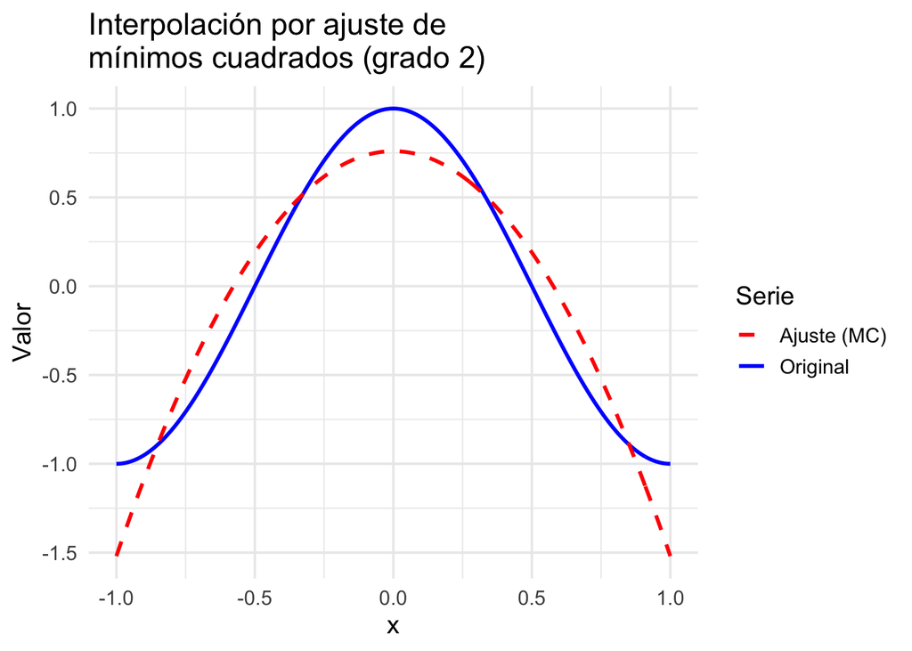

```r
print(grado.2$grafico)
```

```r
# Coeficientes de P4
print(grado.4$coeficientes)
```

```
[1]  0.9783264  0.0000000 -4.4639018  0.0000000  2.5482043
```

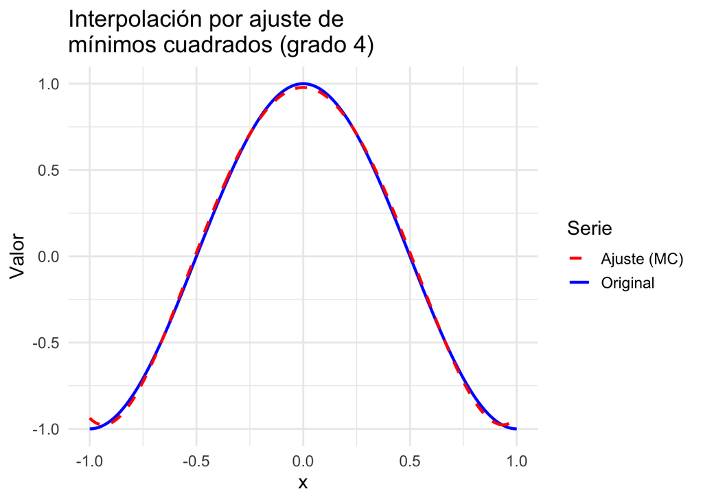

```r
print(grado.4$grafico)
```

```r
# Coeficientes de P6
print(grado.6$coeficientes)
```

```
[1]  0.9989872  0.0000000 -4.8977782  0.0000000  3.8498335  0.0000000 -0.9545280
```

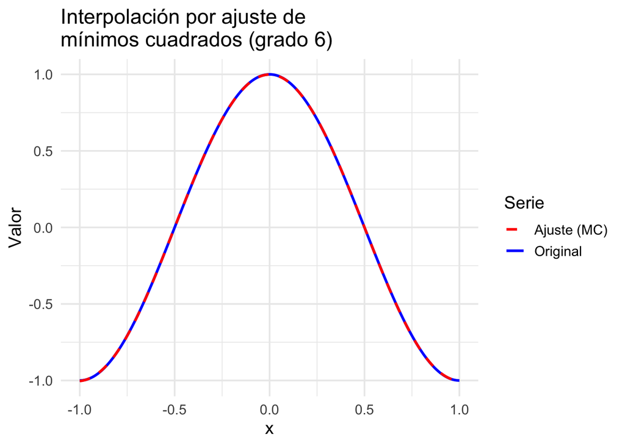

```r
print(grado.6$grafico)
```

# Ejercicio 19

**Instrucción del ejercicio 19**

1. Demuestre que el **Polinomio de Hermite** visto en clase $H_{2n+1}(x)$ es **único**.  
   *Sugerencia:* Suponga que existe otro polinomio $P(x)$ que cumple las condiciones de interpolación de Hermite y considere $D=H_{2n+1}(x)-P(x)$ y $D'$ en $x_0,x_1,\ldots,x_n$.
2. Demuestre que el **error absoluto** en este caso está dado por:

$$\big|f(x)-H_{2n+1}(x)\big| \;=\;
\left|\frac{(x-x_0)^2\cdots(x-x_n)^2}{(2n+2)!}\, f^{(2n+2)}(\xi)\right|,
\quad \text{con } \xi\in(a,b) .$$

**Sugerencia:** Use el mismo método que usamos para demostrar la fórmula del error absoluto en el caso de Lagrange, pero con:

$$g(t)=f(t)-H_{2n+1}(t)\;-\;
\frac{(t-x_0)^2\cdots(t-x_n)^2}{(x-x_0)^2\cdots(x-x_n)^2}
\Big[f(x)-H_{2n+1}(x)\Big].$$